Econometrics and Statistics (520K)

# Econometric Methods in Business and Economics

Practical Class (Winter 24/25)

by Domenic Franjic

# Exercise Sheet No 10 (Mock Exam Part II)

Instrumental Variable Regression

## Set-Up

1) Create your (working) directory

Create a new folder on your computer in which you can save all necessary files, i.e., the data set, the R *script* with the implementation of your analysis and the R *helper function script* with some helper functions provided by us.

This folder, i.e., the path or directory of this folder, will be your so-called working directory.

2) Download the data set

Download the data set `Cigarettes_data.txt` from ILIAS directly or by using the link below:

[Download `Cigarettes_data.txt`](https://ilias.uni-hohenheim.de/goto.php?target=file_1555582_download&client_id=UHOH)

Save the data set into a (working) directory of your choice.

3) Prepare *script*

Open a new R *script* and save it into into your (working) directory.

Run the following code chunk to prepare your R *script*, i.e., to clear the work space and set your working directory.

```r
# Clear workspace
rm(list = ls(all = TRUE))
# Set working directory
setwd(".../set/your/working/directory/...")
```

4) Install/load *packages* and download/save/include *helper function script*

Step 1) Install all relevant R *packages* and download and save the R *script* `r_helper_functions.R` from ILIAS by running the following code chunk.

```r
# Download R-helper functions
source("https://ilias.uni-hohenheim.de/data/UHOH/lm_data/lm_1856939/MA_EconometricMethods_WiSe2324_PracticalClass/r-scripts/prepare_r_packages_and_helper_functions.R")
```

*Note*, the required R *packages* are `"moments"`, `"sandwich"`, `"lmtest"`, `"lmtest"`, `"car"`, `"plm"`, `"ivreg"`, `"dynlm"`, `"forecast"`, `"urca"`.

Step 2) Include the R *script* `r_helper_functions.R` into your R *script* by running the following code chunk.

```r
# Include R-helper functions
source("r_helper_functions.R")
```

*Note*, more information on the helper functions can be found here.

## Task

Demand for Cigarettes

We want to analyze the elasticity of the demand for cigarettes. For this the first Table below shows the estimation results based on the $48$ continental US states in 1995 with observations about the variables described in the second Table below

| Variable | Description |
| --- | --- |
| $packs$ | Number of packs per capita. |
| $rprice$ | Average real price per pack of cigarettes (including tax). |
| $SalesTax$ | General sales tax (real). |
| $rincome$ | State personal income (total, real). |
| $CigTax$ | Special tax on cigarettes and other tobacco products (real). |

```
##
## ===========================================================
##               log(packs)      log(price)     log(packs)
## -----------------------------------------------------------
## Intercept     10.339 (0.935)  4.103 (0.088)   9.895 (1.097)
## log(rprice)   -1.213 (0.195)
## SalesTax                      0.011 (0.002)
## log(rincome)                  0.108 (0.040)   0.280 (0.271)
## CigTax                        0.009 (0.001)
## X_2                                          -1.277 (0.286)
## -----------------------------------------------------------
## R^2            0.406          0.940           0.337
## Adj. R^2       0.393          0.936           0.307
## SER            0.190          0.032           0.203
## ===========================================================
```

### Task a)

Discuss the strategy of regressing $packs$ on $rprice$ using OLS in Table 1 of the Exercise Sheet to identify the elasticity of the demand for cigarettes w.r.t. the price of cigarettes.

What is problematic about this strategy?

Simple OLS Estimation

```r
# Simple OLS
lm.res.01 <- lm_ct_fun(log(packs) ~ log(rprice), data = cig.dat, hc.type = "HC1")
lm.res.01$ct
```

```
##
## t test of coefficients:
##
##             Estimate Std. Error t value  Pr(>|t|)
## (Intercept) 10.33892    0.93482 11.0598 1.502e-14 ***
## log(rprice) -1.21306    0.19459 -6.2339 1.290e-07 ***
## ---
## Signif. codes:  0 '***' 0.001 '**' 0.01 '*' 0.05 '.' 0.1 ' ' 1
```

[output not shown]

Supply and demand

- Price $rprice$ and quantity $packs$ are determined by the interaction of demand and supply of cigarettes
- $\Rightarrow$ Thus, regressing $packs$ on $price$ results in simultaneous causality bias!

Problem

- $\mathrm{E}\left(u|X=x\right) \neq 0$
- $\Rightarrow$ $X$ is correlated with the error term $u$.

*Add your Interpretation here!*

Simultaneous causality bias

*Simultaneous causality bias* in the OLS regression of $ln\left(Q^{cig}\right)$ on $ln\left(P^{cig}\right)$ arises because price and quantity are determined by the interaction of *demand* and *supply*.

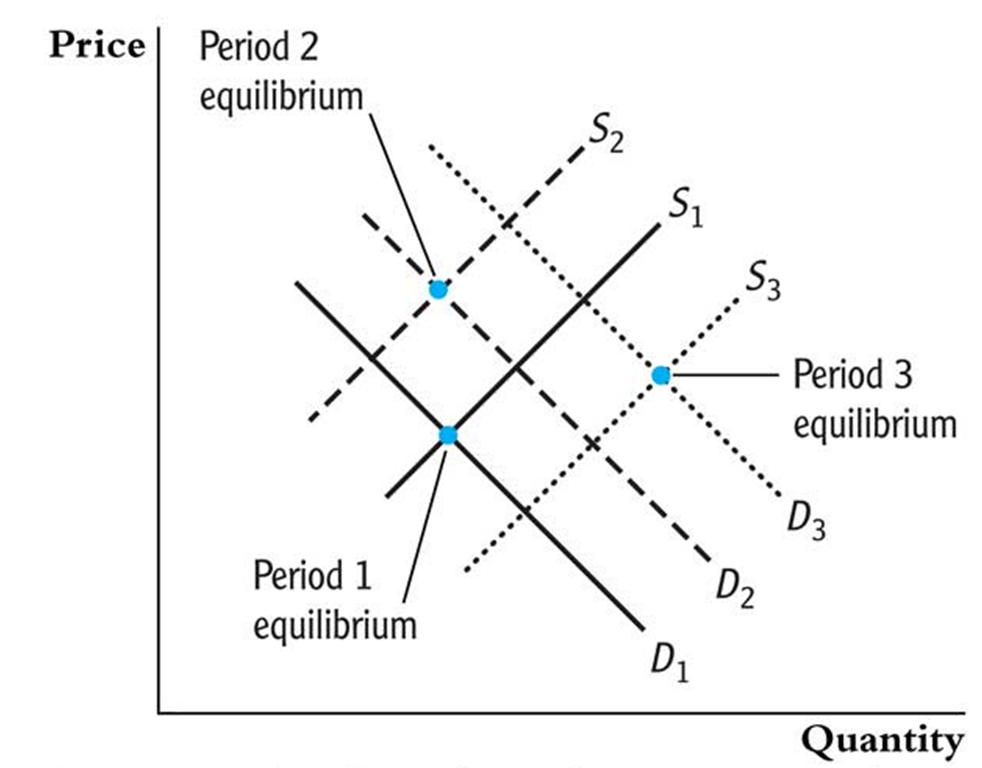

Source: Stock and Watson (2020) on p. 433

Interaction of demand and supply produces…

Would a *regression* using these data produce the *demand curve*?

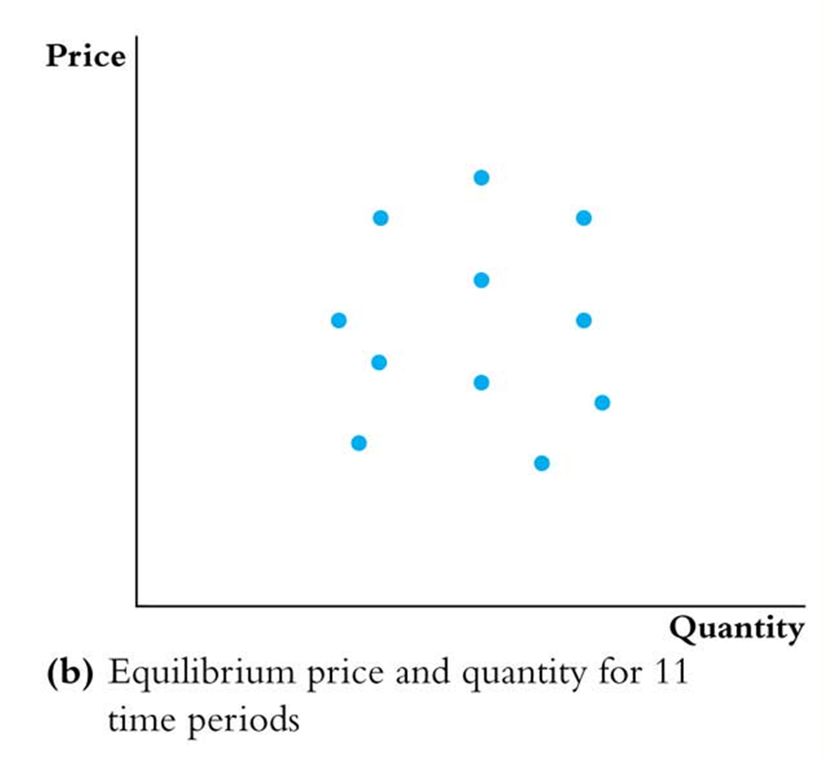

Source: Stock and Watson (2020) on p. 433

Idea

What would we get if only *supply* shifted?

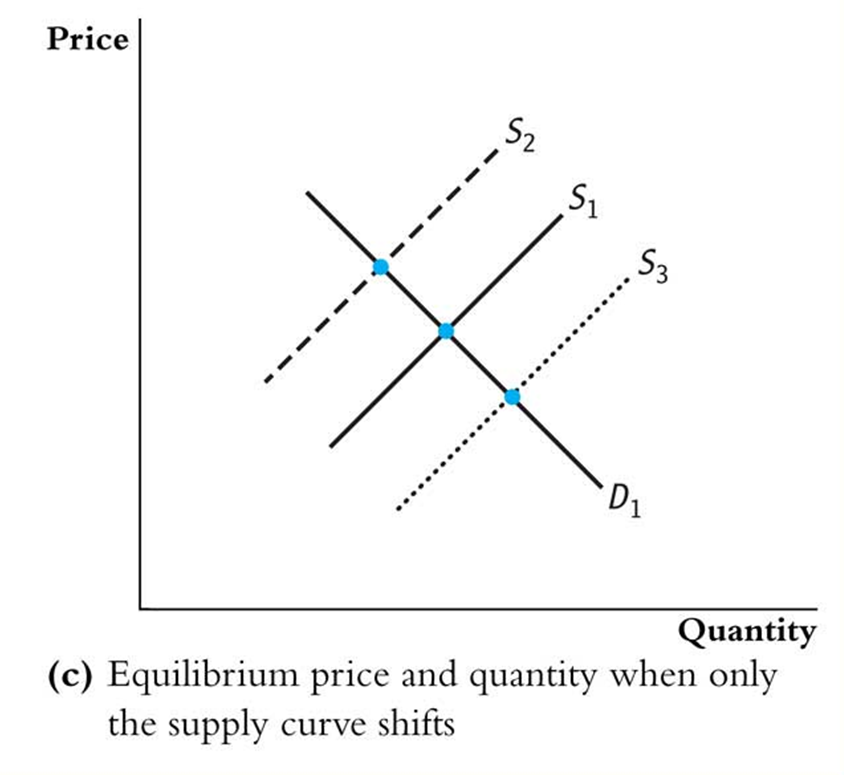

Source: Stock and Watson (2020) on p. 433

Solution

Use an *instrumental variable* $Z$ that only shifts *supply* but not *demand*!

### Task b)

Briefly explain the concept of instrumental variable regression and how it can be used to overcome the problem of endogenous regressors in general.

General

$$\begin{align}
Y_i = \beta_0 + \beta_1 X_i + u_i
\end{align}$$

- Break variation of $X$ into two parts:
  - Part I: Correlated with $u$.
  - Part II: Uncorrelated with $u$.
- Identify part II using an instrument $Z$.

Application

$$\begin{align}
ln\left(Q^{D}\right) = \beta_0 + \beta_1 ln\left(P\right) +
u^{ln\left(Q^D\right)}
\end{align}$$

- Break variation of $ln\left(P\right)$ into two parts:
  - Part I: Correlated with $u^{ln\left(Q^D\right)}$.
  - Part II: Uncorrelated with $u^{ln\left(Q^D\right)}$.
- Use $SalesTax$ for the identification of part II.

*Add your Interpretation here!*

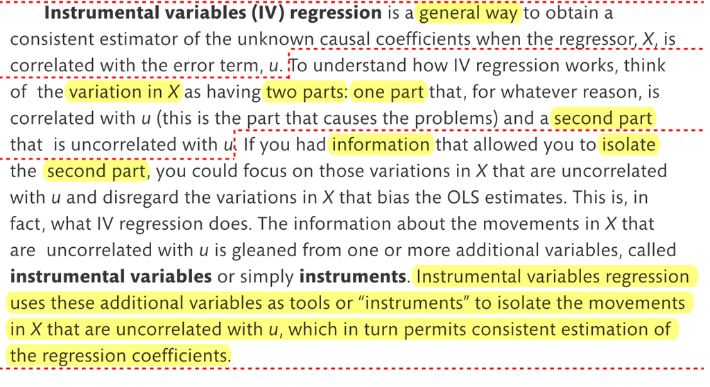

Source: Stock and Watson (2020) on p. 433

### Task c)

State the conditions for variables to be valid instruments in general. Briefly discuss if the variables $SalesTax$ and $CigTax$ fulfills the conditions in the case of analyzing the elasticity of the demand for cigarettes w.r.t. the price of cigarettes.

Conditions

General

1. Instrument relevance: $\mathrm{Cor}\left(Z_i,X_i\right) \neq 0$
2. Instrument exogeneity: $\mathrm{Cor}\left(Z_i,u_i\right) = 0$

Application

1. Instrument relevance: $SalesTax$ and $CigTax$ is included in $rprice$ and thus relevant.
2. Instrument exogeneity:
   - Both have arguably no direct effect on the demand of cigarettes.
   - Both have arguably only an indirect effect on the demand of cigarettes through the price of cigarettes.
   - The choice for the level of the $SalesTax$ and $CigTax$ is driven by political considerations, not by factors related to the demand for cigarettes.
   - Note: If the tax would be specific on cigarettes and interpreted as a signal that smoking is bad, this condition is no longer valid.

Remember

In the supply and demand illustration above, an increase in $SalesTax$ and or $CigTax$ …

… (1) shifts the supply curve up ($\Rightarrow$ instrument relevance)…

… (2) but has no effect on the demand curve ($\Rightarrow$ instrument exogeneity).

*Add your Interpretation here!*

### Task d)

Outline the strategy of Two-Stage Least Squares (2SLS) to analyze the the elasticity of the demand for cigarettes using the variables $SalesTax$ and $CigTax$ as instruments based on the results depicted in Table 1 of the Exercise Sheet. For this state the estimated first and second stage regression. What represents the variable denoted $X_2$ in the second stage regression in Table 1 of the Exercise Sheet? What is the estimated elasticity of the demand for cigarettes?

First Stage Estimation

```r
# 1st stage regression
lm.res.02 <- lm_ct_fun(log(rprice) ~ salestax + log(rincome) + cigtax, data = cig.dat, hc.type = "HC1")
lm.res.02$ct
```

```
##
## t test of coefficients:
##
##               Estimate Std. Error t value  Pr(>|t|)
## (Intercept)  4.1030339  0.0883803 46.4248 < 2.2e-16 ***
## salestax     0.0108898  0.0021366  5.0968 6.999e-06 ***
## log(rincome) 0.1083449  0.0396526  2.7324  0.009019 **
## cigtax       0.0093517  0.0008698 10.7515 6.820e-14 ***
## ---
## Signif. codes:  0 '***' 0.001 '**' 0.01 '*' 0.05 '.' 0.1 ' ' 1
```

```
##
## ================================
##               log rprice
## --------------------------------
## intercept      4.103 (0.088) ***
## SalesTax       0.011 (0.002) ***
## log(rincome)   0.108 (0.040) **
## cigtax         0.009 (0.001) ***
## --------------------------------
## R^2            0.940
## Adj. R^2       0.936
## Num. obs.     48
## SER            0.032
## ================================
## *** p < 0.001; ** p < 0.01; * p < 0.05
```

Second Stage Estimation

```r
# 2nd stage regression
lm.res.03 <- lm_ct_fun(log(packs) ~ lm.res.02$fitted.values + log(rincome), data = cig.dat, hc.type = "HC1")
lm.res.03$ct
```

```
##
## t test of coefficients:
##
##                         Estimate Std. Error t value  Pr(>|t|)
## (Intercept)              9.89496    1.09732  9.0174 1.197e-11 ***
## lm.res.02$fitted.values -1.27742    0.28572 -4.4709 5.230e-05 ***
## log(rincome)             0.28040    0.27077  1.0356    0.3059
## ---
## Signif. codes:  0 '***' 0.001 '**' 0.01 '*' 0.05 '.' 0.1 ' ' 1
```

```
##
## ================================
##               log packs
## --------------------------------
## intercept      9.895 (1.097) ***
## X_2           -1.277 (0.286) ***
## log(rincome)   0.280 (0.271)
## --------------------------------
## R^2            0.337
## Adj. R^2       0.307
## Num. obs.     48
## SER            0.203
## ================================
## *** p < 0.001; ** p < 0.01; * p < 0.05
```

2-Sage-Least-Squares

```r
# IV: first and second stage
iv.res.01 <- ivreg_ct_fun(log(packs) ~ log(rprice) + log(rincome)| salestax + cigtax + log(rincome), data = cig.dat, hc.type = "HC1")
iv.res.01$ct
```

```
##
## t test of coefficients:
##
##              Estimate Std. Error t value  Pr(>|t|)
## (Intercept)   9.89496    0.95922 10.3157 1.947e-13 ***
## log(rprice)  -1.27742    0.24961 -5.1177 6.211e-06 ***
## log(rincome)  0.28040    0.25389  1.1044    0.2753
## ---
## Signif. codes:  0 '***' 0.001 '**' 0.01 '*' 0.05 '.' 0.1 ' ' 1
```

```
##
## ========================================================================
##               log(packs)          log(price)          log(packs)
## ------------------------------------------------------------------------
## Intercept     10.339 (0.935) ***   4.103 (0.088) ***   9.895 (1.097) ***
## log(rprice)   -1.213 (0.195) ***
## SalesTax                           0.011 (0.002) ***
## log(rincome)                       0.108 (0.040) **    0.280 (0.271)
## CigTax                             0.009 (0.001) ***
## X_2                                                   -1.277 (0.286) ***
## ------------------------------------------------------------------------
## R^2            0.406               0.940               0.337
## Adj. R^2       0.393               0.936               0.307
## Num. obs.     48                  48                  48
## SER            0.190               0.032               0.203
## ========================================================================
## *** p < 0.001; ** p < 0.01; * p < 0.05
```

1st Stage Regression

$$\begin{align*}
\small log\left(rprice_i\right) = \beta_0 + \beta_{SalesTax} SalesTax_i
+ \beta_{CigTax} CigTax_i + \beta_{rincome} log\left(rincome_i\right) +
u_i^{log\left(rprice_i\right)}
\end{align*}$$

2nd Stage Regression

$$\begin{align*}
\small log\left(packs_i\right) = \beta_0 + \beta_{rincome}
log\left(rincome_i\right) + \beta_{X_2} X_{2i} + u_i
\end{align*}$$

with $X_{2i} \equiv \widehat{log\left(rprice\right)}_i$, i.e., $X_2$ represents the fitted values of the first stage regression.

Results

- The estimated elasticity of the demand for cigarettes is $-1.28$
- I.e., a $1 \%$ price increase in cigarettes decreases demand for cigarettes by $1.28 \%$.

Role of: $log\left(rincome_i\right)$

- Income is an obvious determinant of demand in general.
- Thus, income is a demand shifter and not a valid instrument for the identification of the demand curve.
- However, income is a useful control variable for both the 1st and 2nd stage regression to counter potential omitted variable bias.

*Add your Interpretation here!*

### Task e)

Briefly discuss the validity of the variables $SalesTax$ and $CigTax$ as instruments based on the test results depicted in Table 2 of the Exercise Sheet which is based on the first stage regression depicted in Table 1 of the Exercise Sheet.

Validity of Instrument

```r
# heteroskedasticity-robust F-test
lin.hyp.01 <- linearHypothesis(lm.res.02, c("salestax", "cigtax"), white.adjust = "hc1")
lin.hyp.01
```

[output not shown]

```r
# heteroskedasticity-robust F-test
lin.hyp.01 <- linearHypothesis(lm.res.02, c("salestax", "cigtax"), white.adjust = "hc1")
lin.hyp.01
```

```
## Linear hypothesis test
##
## Hypothesis:
## salestax = 0
## cigtax = 0
##
## Model 1: restricted model
## Model 2: log(rprice) ~ salestax + log(rincome) + cigtax
##
## Note: Coefficient covariance matrix supplied.
##
##   Res.Df Df      F    Pr(>F)
## 1     46
## 2     44  2 209.68 < 2.2e-16 ***
## ---
## Signif. codes:  0 '***' 0.001 '**' 0.01 '*' 0.05 '.' 0.1 ' ' 1
```

Validity requires

- Instrument exogeneity
- Instrument relevance

We cannot explicitly check for exogeneity but we could check relvance using a *F*-test.

*F*-test (general)

*F*-test (paticular)

Hypothesis:

$$\begin{align}
H_0&: \quad \beta_{SalesTax} = \beta_{CigTax} = 0 \quad \text{vs.}
\\
H_1&: \quad \text{at least one} \neq 0
\end{align}$$

based on 1st stage regression

Test statistic value:

$$\begin{align}
F^{act}\left( 2, 44 \right) &= 209.676
\end{align}$$

Conclusion:

$$\begin{align}
F^{act}\left( 2, 44 \right) > 10
\end{align}$$

$\Rightarrow$ Together the variables $SalesTax$ and $CigTax$ are not weak!

*Add your Interpretation here!*

Critical value for the $\underline{F\left(m,\infty\right)}$

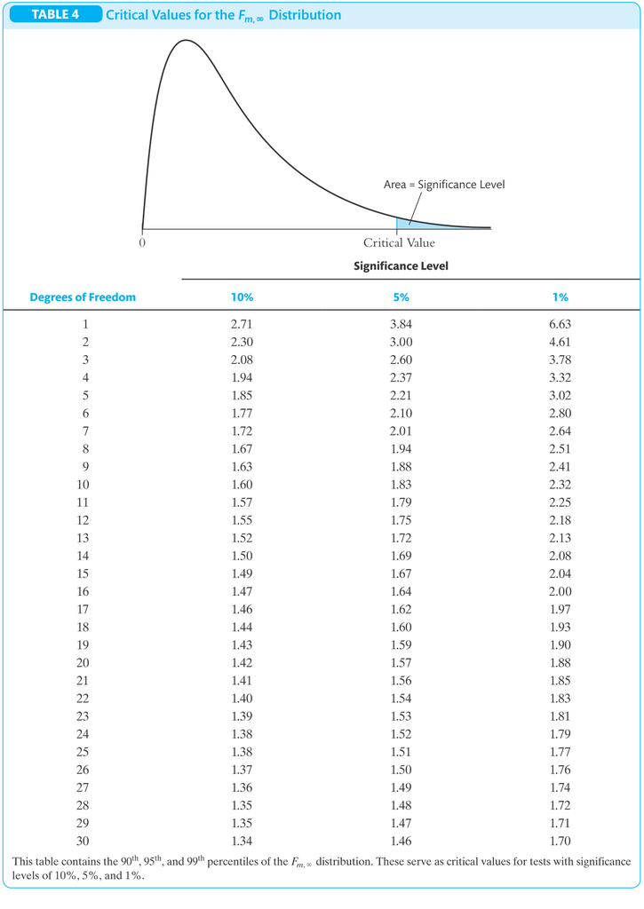

Source: Stock and Watson (2020) on p. 767

Back To *Start*